# 店舗立地と商品価格

都心店，準都心店，通常店

岩田真一郎（神奈川大学経済学部）

2023-08-17作成，2024-03-17改訂

［PDF形式：489KB］

全国展開するチェーン店形式の外食企業の多くは立地にかかわらず同一商品を同一価格で提供するのが一般的です．企業は，どこで食べても（同じ味を）同じ値段で購入できる安心感を消費者に与え，消費者を獲得しているのかもしれません．しかし，外食大手のマクドナルドは都心部に立地する店舗の商品価格を$2023$年$7$月$19$日より見直すことを発表しました（日本マクドナルド株式会社，$2023$）．関（$2023$）は『日経ビジネス』の記事の中で，マクドナルドが標準の価格で提供する「通常店」より高価格で売る「都心店」，両者の中間的な位置づけの「準都心店」を新たに設定したことを紹介しています．例えば，ビックマックの価格は通常店が$450$円ですが，準都心店は$20$円，都心店は$50$円それぞれ高くなるようです．

価格帯の異なる都心店や準都心店を設定した理由としては賃料が挙げられています．そこで，マクドナルドの価格設定と土地の賃料（地代）の関係を確認しておきましょう．残念ながら賃料の情報は手に入らないため，地価の情報で代替します．[住宅と住宅政策](https://shinichiro-iwata.github.io/lecture-notes-urban-econ/housing-price-and-policy.html)でも述べたように，土地を賃貸する際に支払う地代が高くなると，土地を購入・所有する際に支払う地価も高くなります．図$1$は横浜市西区，中区，神奈川区のマクドナルドの価格帯別店舗と$2023$年の商業地地価の分布を示しています．[^1]商業地地価は西区の横浜駅周辺が最も高く，マクドナルドもこの周辺に立地する$3$店舗を都心店としています．その他，相対的に地価の高い西区のみなとみらいに立地する$2$店舗や，中区の関内駅周辺に立地する$2$店舗，観光地でもある赤レンガ倉庫，山下公園，横浜中華街にそれぞれ立地する$3$店舗が準都心店に設定されています．一方，地価の相対的に低い神奈川区に立地する$5$店舗，中区の関内駅や観光地から外れた地域に立地する$3$店舗は通常店のままになっています．このように地代が高いために地価の高い場所では設定する商品価格を高くし，地代が低いために地価の低い場所では商品価格を据え置いているようです．

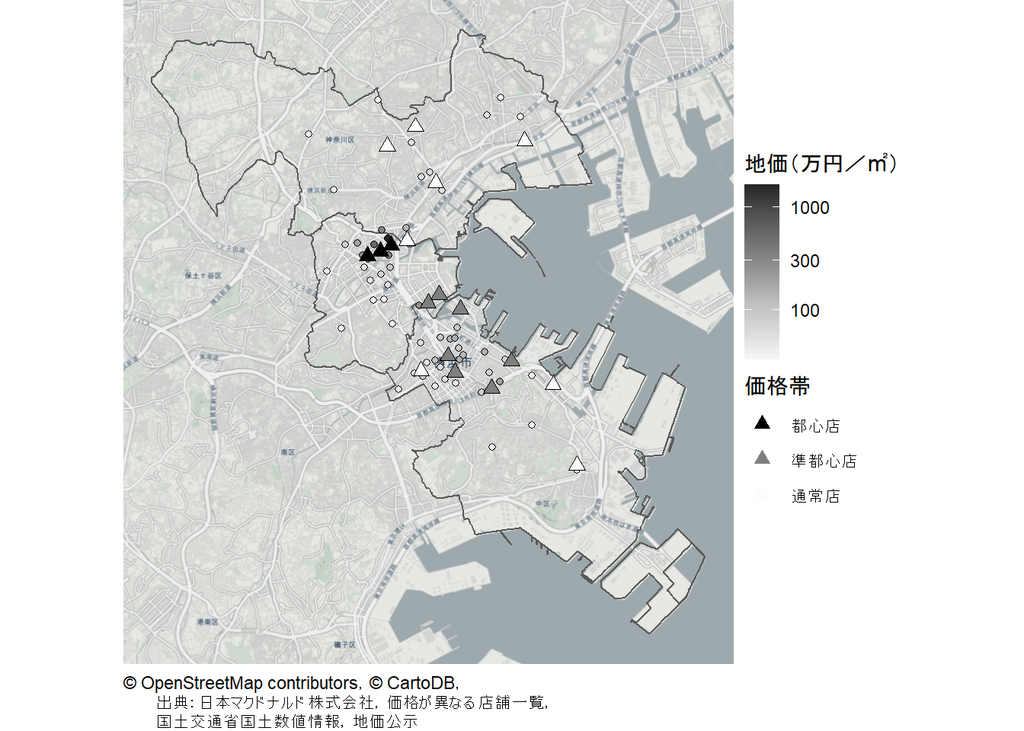

図1：横浜市西区，中区，神奈川区のマクドナルド店舗と商業地地価

「都心では賃料が高いから商品の価格を高くする」というのは納得のいく説明のように思われます．しかし，経済学では「商品が高く売れるから，都心の賃料が高くなる」と考えます．そこで，本稿の第$1$節から第$2$ではこの関係を説明しましょう．続く第$3$節では，同一の仕事をする労働者の賃金（アルバイト賃金）が立地によって異なる理由も同じように説明できることを紹介します．

# 1 企業の土地需要

企業は土地（店舗）を借りて商品（ハンバーガー）を生産します．このとき，企業は土地から得られる便益と土地への支出を差し引いた純利益を最大にするように土地投入（需要）量を決定します．土地投入量$l$は面積あたりで考え，面積あたりの賃料を$R$とすると，土地への支出は$Rl$になります．先に述べた純利益は [住宅と住宅政策](https://shinichiro-iwata.github.io/lecture-notes-urban-econ/housing-price-and-policy.html)で学んだ消費者余剰に似ています．実際に企業は土地市場において土地を消費する買い手として行動します．

図$2$は企業の個別土地需要曲線が描かれています．図$2$では，賃料が$R^*$の場合，企業は$l^*$の土地を消費します．このとき，消費者余剰は面積$AeR^*$（便益$Ael^*O-$支出$R^*el^*O$）で最大になります．

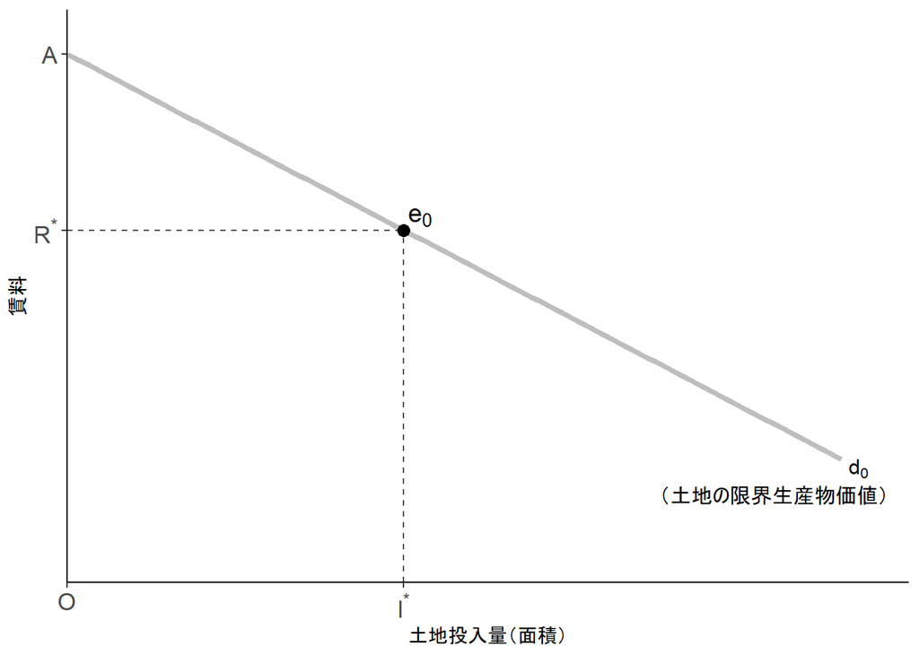

図2：個別企業の土地需要曲線

話をわかりやすくするために，これまで消費者余剰という言葉を使ってきました．実はこれを生産者余剰として表現できます．生産者余剰は収入から費用を差し引くことで求まりました．商品の価格を$P$，生産量を$x$で表すと，収入は$Px$になります．完全競争市場では企業は価格受容者として行動するため，収入を増やすためには商品の生産量を拡大する必要があります．そのためには，土地（店舗）を投入し（借り）なければなりません．このことは，生産量が土地投入量に依存することを意味します．そこで，生産量と土地投入量の関係を$X=f(l)$と表しましょう．ここで，$f(l)$は**生産関数**とよばれます．$f(l)$はどのような形状になるでしょうか？投入する土地面積を追加的に増やしてゆくと，商品の数は増えてゆきますが，増加分（これを土地の**限界生産物**とよびます）は一定とは限りません．なぜなら，投入量が少ないうちは生産に最も適した区画を選べますが，投入量を増やしていくと，生産にあまり適さない区画を選ばざるを得なくなる可能性が高くなるからです．この場合，投入量の追加的な増加とともに商品の増加分を示す土地の限界生産物は小さくなっていきます（**限界生産物逓減**）．一方，費用は先ほど示した支出$Rl$に等しくしなります．以上から生産者余剰は次式のように表せます．
$$Pf(l)-Rl$$
生産者余剰を最大にする土地投入量は，土地面積を追加的に$1$単位増やしたときの収入の増加分と費用の増加分を比較することで求まります．完全競争市場では個別企業が土地投入量を増やして生産量を拡大しても商品価格$P$が変化しないことに注意しましょう．すると，収入の増加分は商品価格に土地の限界生産物を掛け合わせた値に等しくなります．商品価格に投入物の限界生産物を掛け合わせた値は投入物の**限界生産物価値**とよばれます．一方，土地投入量を増やしても面積あたりの賃料$R$は変化しないため，費用の増加分は地代$R$に等しくなります．

企業が土地投入量を追加的に$1$単位増やしたときに仮に土地の限界生産物価値（収入の増加分）が賃料（費用の増加分）より高いとしましょう．このとき，企業は土地投入量を増やすことで生産者余剰を拡大できます．したがって，企業は土地の限界生産物価値が賃料を上回っている限り，土地投入量を増やします．しかし，土地の限界生産物は土地投入量の増加につれて逓減していくため，やがて土地の限界生産物価値が賃料に等しくなります．このとき，生産者余剰はもう増えることはありません．以上から，企業は土地の限界生産物価値が賃料に等しくなるまで土地投入量を増やすことが合理的になります．

# 2 土地市場

## （1）通常店の均衡賃料

通常店では商品（ハンバーガー）が$P_0$で取引されているとしましょう．このとき，図$2$の個別企業の土地需要曲線$d_0$は土地の限界生産物に商品の価格$P_0$を掛け合わせた値に等しくなります.市場土地需要曲線はすべての個別企業の土地需要曲線を水平方向に足し合わせることによって求まります．この市場土地需要曲線が図$3$の$D_0$のように描けたとしましょう．一方，市場土地供給曲線$S_0$は右上がりだと仮定しておきましょう．

通常店が支払う均衡賃料$R_0$は土地市場の市場需要曲線$D_0$と市場供給曲線$S_0$の均衡点$E_0$で決定します．

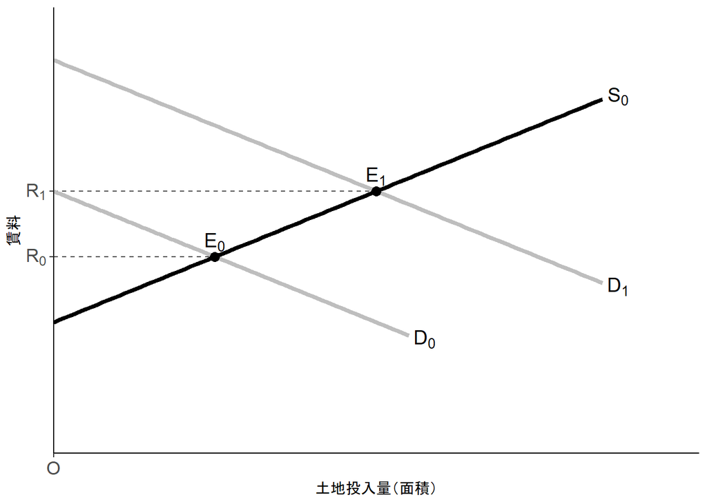

図3：土地市場の均衡

## （2）商品価格の上昇と（準）都心店の均衡賃料

都心店では商品が$P_0$より高い$P_1$で取引されているとしましょう．ここで，都心店では高い価格でも商品を購入する消費者がいることがポイントになります．都心に立地しているにかかわらず，$P_0$（同一価格）でなければ取引できないのであれば，これから話す内容は成立しません．実際に関（$2023$）はビックマックに対する支払いに関して，通常店の客が購入を渋り始めるのが$450$円であるのに対し，都心店は$500$円であること紹介しています．このように都心では高い価格を支払っても商品を購入しようとする人がいるのです．

商品が高く売れると何が起きるでしょうか？このとき，個別企業の土地の限界生産物価値が大きくなります．この結果，個別企業の土地需要曲線が上にシフトします．したがって，仮に賃料が変わらなければ企業は土地の投入量を増やそうとします．都心に立地するすべての企業がこのように土地需要を増やそうとすると，市場土地需要曲線は図$3$の$D_1$のように上方シフトします.この結果，図$3$において，均衡点は$E_1$に移り，都心店が支払う均衡賃料は$R_1$に上昇します．

準都心店では商品が$P_0$と$P_1$の間で取引されます．したがって，準都心店が支払う均衡賃料は$R_0$と$R_1$の間に落ち着くことが予想されます．

以上から，賃料が高いから商品が価格が高くなるのではなく，商品を高く取引できるからこそ，賃料が高くなることが確認できました．そして賃料が高いからこそ，土地を所有することが有利になり，土地の所有価格である地価が高くなるのです．

# 3 店舗の立地点と賃金

$2022$年$10$月$1$日より[神奈川県の最低賃金](https://www.pref.kanagawa.jp/docs/z4r/info/saichin.html#:~:text=%E4%BB%A4%E5%92%8C4%E5%B9%B410,%E8%80%85%E3%81%AB%E9%81%A9%E7%94%A8%E3%81%95%E3%82%8C%E3%81%BE%E3%81%99%E3%80%82)は$1071$円になりました．それではマクドナルドのクルー（パートタイム労働者）の募集時給はどこでも$1071$円になるでしょうか．図$4$は横浜市西区，中区，神奈川区のマクドナルドのクルーの募集時給と$2023$年の商業地地価の分布を示しています．[^2]図$1$の商品の価格帯と完全に一致するわけではありませんが，横浜駅周辺やみなとみらい周辺の店舗のクルー時給は相対的に高く，中区の準都心店がそれに続きますが，その他の店舗は最低賃金に一致していることわかります．すなわち，賃金も一様に分布はしていません．

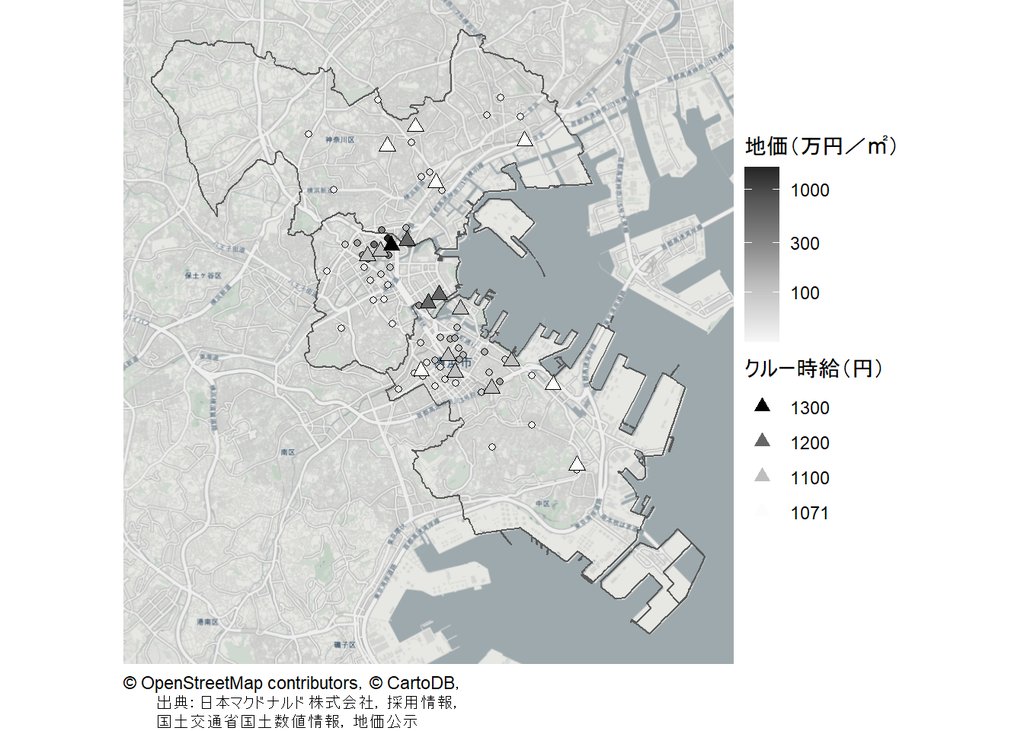

図4：横浜市西区，中区，神奈川区のマクドナルド時給と商業地地価

マクドナルドは価格帯の異なる都心店や準都心店を設定した理由として人件費も挙げています．しかし，賃料同様の話が賃金についても当てはまります．土地投入量を労働投入量に変更すると，個別企業は商品価格に依存する労働の限界生産物価値と賃金が等しくなるように労働投入量を決定します．通常店が支払う均衡賃金は市場労働需要曲線と市場労働供給曲線の交点によって決まります．市場労働需要曲線は個別企業の労働需要曲線を水平方向に足し合わせることによって求まりますので，都心店や準都心店のように商品価格が高くても販売できるような場所では，市場労働需要曲線が上方にシフトします．この結果，都心店や準都心店では支払う均衡賃金が高くなるのです．

図$4$に示したクルーの時給は募集時のものです．最初の採用時はおそらくクルーの仕事内容は同一でしょう．また採用された時点の（準）都心店のクルーの生産性（正確には労働の限界生産物）が通常店のクルーの生産性より高くなるとは考えられません．それにも関わらず立地点によってクルーの時給が異なるのは，消費者の同一商品への支払い許容額が立地点によって異なっていることを反映しています．

# 参考文献

- 日本マクドナルド株式会社（$2023$）[「都心型価格の適用店舗再編のお知らせ」](https://www.mcdonalds.co.jp/company/news/2023/0619a/)$2023$年$6$月$19$日（ニュースリリース）
- 関ひらら（$2023$）[「$50$円高いビッグマックは許容範囲 「都心型価格」の勝算」](https://www.nikkei.com/article/DGXZQOUC072SP0X00C23A8000000/)『日経ビジネス』$2023$年$8$月$9$日

# R環境

**セッション情報**

- R version 4.2.3 (2022-03-15)
  - RStudio 2023.06.1+524
  - rmarkdown_2.21

**使用したパッケージ**

- `ggspatial`，`sf`，`tidyverse`

# リンク

- [都市経済学講義ノート](https://shinichiro-iwata.github.io/lecture-notes-urban-econ/)
- [Rによる地理空間データの可視化](https://shinichiro-iwata.github.io/geospatial-data-visualization/)
- [Shinichiro Iwata](https://shinichiro-iwata.github.io/)

**アイコン**

- Font Awesome 6.3.0
[^1]: マクドナルドの店舗位置を地図上に示すには緯度経度（ジオコード）の情報が必要になります．まず，マクドナルドの店舗住所は[店舗検索](https://map.mcdonalds.co.jp/)から取得しました．次に，[東京大学空間情報科学研究センター](https://www.csis.u-tokyo.ac.jp/)が提供する[$\rm{CSV}$アドレスマッチングサービス](https://geocode.csis.u-tokyo.ac.jp/home/csv-admatch/)を利用して住所情報に対応するジオコードを付加しました．
[^2]: マクドナルドのクルーの募集時給は[採用情報](https://www.mcdonalds.co.jp/recruit/crew_recruiting/)から取得しました．